# Seguridad e higiene

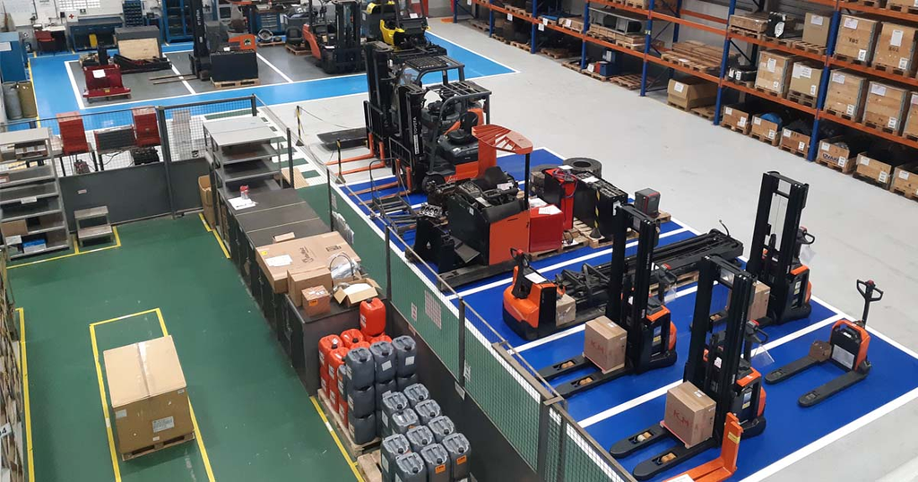

Fábrica 5s - Fuente: toyotaempilhadeiras.com.br

## ¿Por qué importa la seguridad e higiene en el taller?

[figure not shown]

Algo no recomendable - Fuente: dreamstime.com

Trabajar en un taller implica usar herramientas y máquinas que pueden causar accidentes si no se toman precauciones. Mantener el lugar limpio y ordenado no solo reduce riesgos, sino que permite trabajar de manera más eficiente y profesional. Para lograrlo de forma sistemática, los talleres suelen aplicar la metodología 5S, que organiza el trabajo en cinco pasos para mantener todo en su lugar y listo para usarse.

## ¿De dónde viene la metodología 5S?

La metodología 5S nació en Japón, en las fábricas de Toyota, después de la Segunda Guerra Mundial.  
En ese momento había que trabajar con pocos recursos y producir con la mayor eficiencia posible. Los ingenieros notaron que gran parte del tiempo se perdía buscando herramientas o limpiando restos de trabajos anteriores.  
Crearon entonces un sistema para mantener el taller siempre limpio y ordenado, evitando accidentes y desperdicios.  
Ese método se llamó 5S, porque se basa en cinco pasos que en japonés empiezan con “S”.

Observa este [video](https://www.youtube.com/watch?v=TIluVXT0c1s).

## Qué son las 5S

[figure not shown]

Fuente: toyota-indus.com

1. **Seiri – Clasificar:** separar lo necesario de lo que no lo es.
2. **Seiton – Ordenar:** cada cosa en su lugar, para encontrarla rápido y sin peligro.
3. **Seiso – Limpiar:** eliminar polvo, restos de material y suciedad.
4. **Seiketsu – Estandarizar:** mantener reglas simples para que el orden y la limpieza se repitan siempre.
5. **Shitsuke – Disciplina:** formar el hábito de hacerlo todos los días.

Aplicar las 5S ayuda a que el trabajo sea más seguro, productivo y profesional.

## Elementos de Protección Personal (EPP)

La primera protección siempre eres tu mismo: ser responsable y cuidadoso, trabajar de un modo sereno y ordenado. Los EPPs son equipos que protegen al trabajador mientras realiza tareas en el taller. Son útiles pero son auxiliares en el sentido de que solo mitigarán las consecuencias de un accidente. Lo primero siempre será **tu actitud**.

Algunos ejemplos:

- **Guantes:** evitan cortes o quemaduras.
- **Lentes:** protegen los ojos de partículas y chispas.
- **Calzado de seguridad:** previenen lesiones por objetos pesados o punzantes.
- **Protectores auditivos:** cuidan la audición en lugares ruidosos.

**Regla clave:** ningún trabajo comienza sin el EPP correspondiente.

## Limpieza y orden del taller

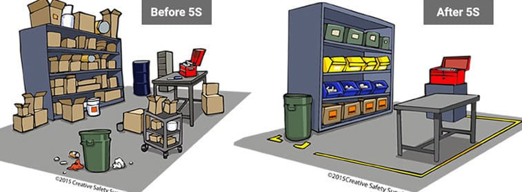

Fuente: fabricavisual.com.mx

Un taller limpio y ordenado:

- Reduce riesgos de accidentes.
- Facilita encontrar herramientas y materiales.
- Evita la acumulación de chatarra y residuos peligrosos.

El mantenimiento se hace todos los días, no solo al final de grandes tareas.

Además la tarea de mantenerlo limpio es tarea de todos. Cada uno **puede y debe**:

- dejar cada cosa en su lugar después de usarla,
- evitar tirar residuos donde no corresponde,
- limpiar y ordenar la herramienta o máquina que estuvo usando,
- contribuir a la limpieza y orden general, etc.

Esto es así en todos los países y lugares (minas, fábricas, talleres, etc.) donde se quiere trabajar de un modo más humano y eficiente.